# Survival Analysis

## 1. Load Packages

```r
library(survival)
library(survminer)
library(stringr)
library(dplyr)
library(MASS)
library(lmtest)
```

## 2. Data

- pharynx : 구강내 악성종양이 있는 환자들을 연구한 기록을 나타낸 데이터이다.

```r
pharynx <- read.csv('pharynx.csv', header=T)

str(pharynx)
```

```
## 'data.frame':    195 obs. of  13 variables:
##  $ CASE    : int  1 2 3 4 5 6 7 8 9 10 ...
##  $ INST    : int  2 2 2 2 5 4 4 4 6 3 ...
##  $ SEX     : int  2 1 1 1 1 1 1 1 1 1 ...
##  $ TX      : int  1 2 1 1 2 2 1 2 1 1 ...
##  $ GRADE   : int  1 1 2 1 2 1 2 3 2 2 ...
##  $ AGE     : int  51 65 64 73 64 61 65 84 54 72 ...
##  $ COND    : int  1 1 2 1 1 1 1 1 2 2 ...
##  $ SITE    : int  2 4 1 1 1 2 2 4 1 4 ...
##  $ T_STAGE : int  3 2 3 4 4 3 4 1 3 2 ...
##  $ N_STAGE : int  1 3 3 0 3 0 3 3 3 2 ...
##  $ ENTRY_DT: int  2468 2968 3368 5768 9568 10668 10768 12068 13368 15468 ...
##  $ STATUS  : int  1 1 1 1 1 0 1 1 1 1 ...
##  $ TIME    : int  631 270 327 243 916 1823 637 235 255 184 ...
```

- pharynx data는 13개의 변수와 195개의 관측치로 구성되어 있음
- `CASE` : 사례 id (각 데이터 또는 환자의 id로 봐도 무방)
- `INST` : 참여 기관 (1~6까지 6개의 기관이 있음)
- `SEX` : 환자의 성별
  - 1 : 남자
  - 2 : 여자
- `TX` : 치료
  - 1 : 방사선치료 + a
  - 2 : 방사선치료
- `GRADE` : 악성종양이 숙주세포와 유사한 정도
  - 1 : 매우
  - 2 : 보통
  - 3 : 저조
  - 9 : 결측치
- `AGE` : 진단 당시의 나이
- `COND` : 진단 당시의 건강 상태
  - 1 : 일상생활에 지장없음
  - 2 : 일상생활이 다소 제한됨
  - 3 : 자기 관리 및 도움 필요
  - 4 : 침대 위
  - 9 : 결측치
- `SITE` : 부위(위치)
  - 1 = faucial arch
  - 2 = tonsillar fossa
  - 3 = posterior pillar
  - 4 = pharyngeal tongue
  - 5 = posterior wall
- `T_STAGE` : 종양 크기에 따른 단계
  - 1 = 최대 직경 2cm 이하의 원발 종양
  - 2 = 최대 직경 2~4cm의 원발 종양
  - 3 = 4cm 이상의 원발 종양
  - 4 = 거대 침습성 종양(-침습성증식 : 분열로 증식하는 종양세포가 주위의 고유조직세포사이에 퍼져가는데 이때 정상조직을 파괴하면서 확대하는 현상)
- `N_STAGE` : 암세포의 전이 정도에 따른 단계
  - 0 = 림프절에 전이한 임상적 증거 없음
  - 1 = 직경 3cm 이하의 양성 노드 1개 존재, 고정되지 않음
  - 2 = 직경 3cm 이상의 양성 노드 1개 존재, 고정되지 않음
  - 3 = 여러 개의 양성 노드 또는 고정된 양성 노드 존재
- `ENTRY_DT` : 연구 시작 날짜: Day of year and year, dddyy
- `STATUS` : censoring 여부
  - 0 = censored
  - 1 = dead
- `TIME` : 진단 당시부터의 생존 시간

## 3. The Purpose of Analysis

- 구강내 악성종양이 있는 환자들의 생존시간 시간을 바탕으로 Cox PH(Proportional Hazard) 모형과 AFT(Accelerated Failure Time) 모형 각각 적합 및 비교

## 4. Data Exploration

- Data를 분석하기 전 데이터의 구성을 살펴보기 위해 Data Exploration를 진행함

### 결측치(NA)

```r
pharynx <- filter(pharynx, pharynx$GRADE != 9,  pharynx$COND != 0, pharynx$COND != 9)  # missing value
str(pharynx)
```

```
## 'data.frame':    192 obs. of  13 variables:
##  $ CASE    : int  1 2 3 4 5 6 7 8 9 10 ...
##  $ INST    : int  2 2 2 2 5 4 4 4 6 3 ...
##  $ SEX     : int  2 1 1 1 1 1 1 1 1 1 ...
##  $ TX      : int  1 2 1 1 2 2 1 2 1 1 ...
##  $ GRADE   : int  1 1 2 1 2 1 2 3 2 2 ...
##  $ AGE     : int  51 65 64 73 64 61 65 84 54 72 ...
##  $ COND    : int  1 1 2 1 1 1 1 1 2 2 ...
##  $ SITE    : int  2 4 1 1 1 2 2 4 1 4 ...
##  $ T_STAGE : int  3 2 3 4 4 3 4 1 3 2 ...
##  $ N_STAGE : int  1 3 3 0 3 0 3 3 3 2 ...
##  $ ENTRY_DT: int  2468 2968 3368 5768 9568 10668 10768 12068 13368 15468 ...
##  $ STATUS  : int  1 1 1 1 1 0 1 1 1 1 ...
##  $ TIME    : int  631 270 327 243 916 1823 637 235 255 184 ...
```

- 결측치가 있는 데이터는 분석에서 제외하여, 총 192개의 관측치로 구성된다.

### Event(사망) 비율 탐색

```r
data.frame(N = nrow(pharynx), Event = sum(pharynx$STATUS==1), Censored = sum(pharynx$STATUS==0),
           Ratio = round(sum(pharynx$STATUS==1)/nrow(pharynx), digits = 2))
```

```
##     N Event Censored Ratio
## 1 192   139       53  0.72
```

- 전체 192개의 관측치 중 Event(사망)는 139개가 발생하였고, 53개는 Censored되어 전체 데이터 중 Event는 약 72% 정도 발생하였다.

### Kaplan Meier Curve

- 추후 Cox PH 및 AFT 모형 적합시 그룹간 Curve의 차이가 비교적 뚜렷하게 존재하는 편이 더 좋은 결과를 도출하고 해석을 용이하게 할 수 있다.
- 범주형으로 구성되어 있는 설명변수의 경우 Kaplan Meier Curve와 범주의 의미 및 순서를 고려하여 새로운 범주를 부여 후 분석을 진행하였다.
- 새로운 범주를 부여한 설명변수 : `GRADE`, `COND`, `T_STAGE`, `N_STAGE`
- 기존 범주를 이용한 설명변수
  - `INST`, `SITE` : 새로운 범주 부여시 의미 해석이 난해하여 범주를 재구성하지 않음.
  - `SEX`, `TX` : 기존 범주가 2개이므로 범주 재구성에 대한 필요성 없음.

#### `GRADE(악성종양과 숙주세포의 유사정도)`

- GRADE의 Kaplan Meier Curve

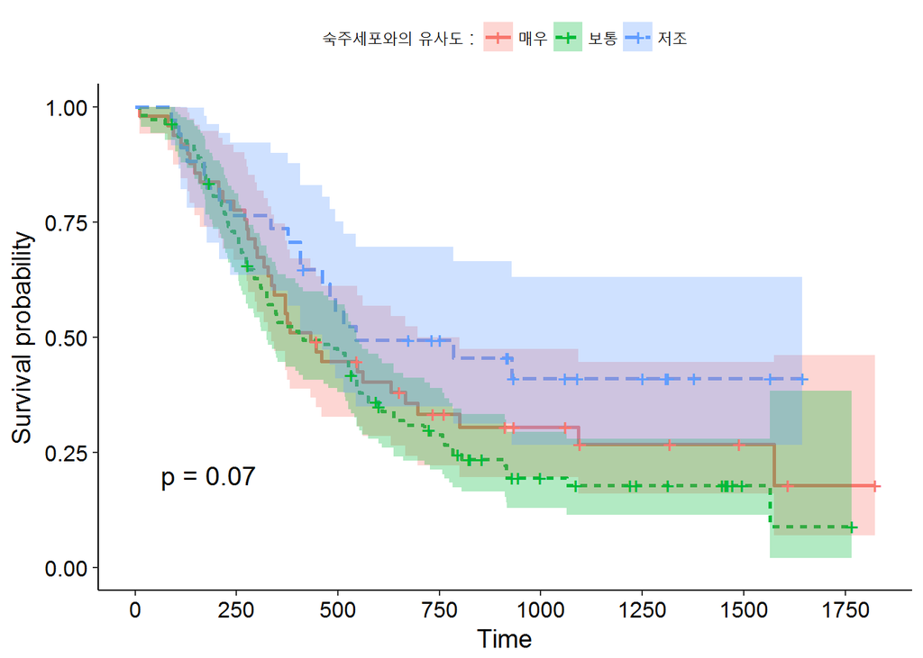

```r
attach(pharynx)
Y <- Surv(TIME, STATUS)

KM_GRADE = survfit(Y ~ GRADE)
ggsurvplot(KM_GRADE, conf.int = T, break.time.by = 250, linetype = 'strata', legend.title = '숙주세포와의 유사도 :', legend.labs = c('매우', '보통', '저조'), pval = T)
```

```r
survdiff(Y ~ GRADE)
```

```
## Call:
## survdiff(formula = Y ~ GRADE)
##
##           N Observed Expected (O-E)^2/E (O-E)^2/V
## GRADE=1  49       35     36.4    0.0514    0.0701
## GRADE=2 109       85     73.6    1.7588    3.7790
## GRADE=3  34       19     29.0    3.4552    4.3967
##
##  Chisq= 5.3  on 2 degrees of freedom, p= 0.0702
```

- 악성종양과 숙주세포간 유사성이 저조한 경우의 Kaplan Meier Curve가 타그룹의 Curve에 비해 비교적 뚜렷하게 다른 것을 확인할 수 있다.
- `GRADE` 범주의 의미와 순서를 고려하여 악성종양이 숙주세포와 보통 이상 유사하면 1(유사), 그렇지 않으면 2(유사하지 않음)으로 재구성하여 Kaplan Meier Curve를 다시 그린 결과는 다음과 같다.

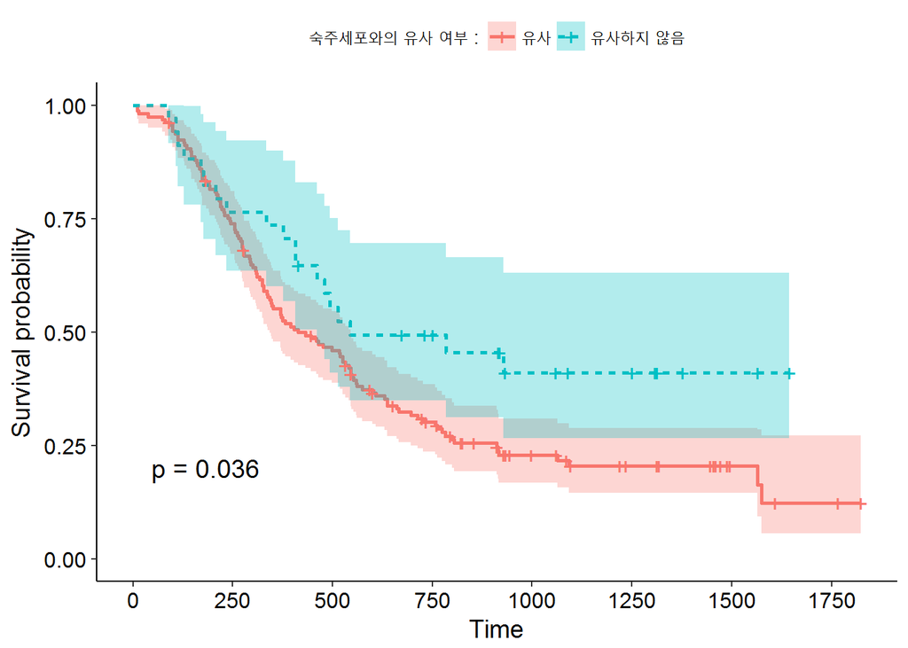

```r
GRADE[GRADE <= 2] <- 1
GRADE[GRADE == 3] <- 2

KM_GRADE = survfit(Y ~ GRADE)
ggsurvplot(KM_GRADE, conf.int = T, break.time.by = 250, linetype = 'strata', legend.title = '숙주세포와의 유사 여부 :', legend.labs = c('유사', '유사하지 않음'), pval = T)
```

```r
survdiff(Y ~ GRADE)
```

```
## Call:
## survdiff(formula = Y ~ GRADE)
##
##           N Observed Expected (O-E)^2/E (O-E)^2/V
## GRADE=1 158      120      110     0.911       4.4
## GRADE=2  34       19       29     3.455       4.4
##
##  Chisq= 4.4  on 1 degrees of freedom, p= 0.036
```

#### `COND(진단 당시의 건강상태)`

- `COND`의 Kaplan Meier Curve

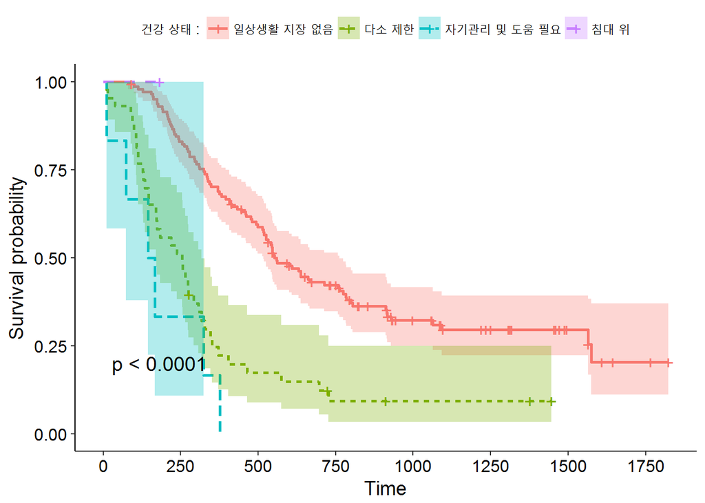

```r
KM_COND = survfit(Y ~ COND)
ggsurvplot(KM_COND, conf.int = T, break.time.by = 250, linetype = 'strata', legend.title = '건강 상태 :', legend.labs = c('일상생활 지장 없음', '다소 제한', '자기관리 및 도움 필요', '침대 위'), pval = T)
```

```r
survdiff(Y ~ COND)
```

```
## Call:
## survdiff(formula = Y ~ COND)
##
##          N Observed Expected (O-E)^2/E (O-E)^2/V
## COND=1 142       95  120.427     5.369    41.446
## COND=2  43       38   17.059    25.706    29.992
## COND=3   6        6    1.331    16.378    16.701
## COND=4   1        0    0.182     0.182     0.184
##
##  Chisq= 49.1  on 3 degrees of freedom, p= 1.24e-10
```

- 환자의 건강상태가 일상생활에 지장이 없는 경우의 Kaplan Meier Curve가 다소 제한된 경우의 Curve에 비해 비교적 뚜렷하게 다른 것을 확인할 수 있다.
- 나머지 그룹(자기관리 및 도움 필요, 침대 위)의 경우 데이터가 부족하여 그래프상에서 위와같은 형태로 나타났다.
- 어느 한 범주라도 데이터가 매우 부족하면 p-value에 큰 영향을 주어 결과 해석이 달라질 수 있다.
- `COND` 범주의 의미와 순서를 고려하여 일상생활에 지장이 없으면 1, 지장이 있으면(나머지 그룹 모두) 2로 재구성하여 Kaplan Meier Curve를 다시 그린 결과는 다음과 같다.

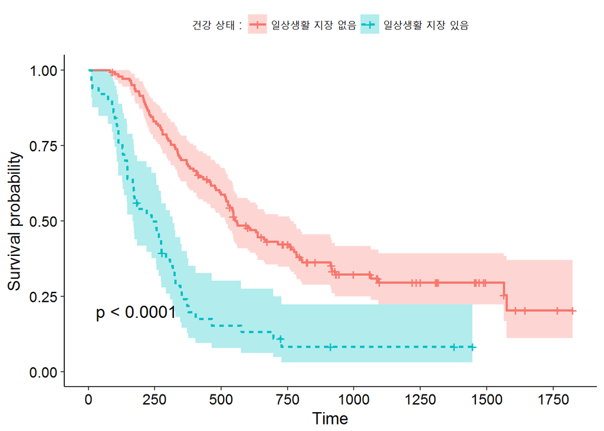

```r
COND[COND == 1] <- 1
COND[COND >= 2] <- 2
KM_COND = survfit(Y ~ COND)
ggsurvplot(KM_COND, conf.int = T, break.time.by = 250, linetype = 'strata', legend.title = '건강 상태 :', legend.labs = c('일상생활 지장 없음', '일상생활 지장 있음'), pval=T)
```

```r
survdiff(Y ~ COND)
```

```
## Call:
## survdiff(formula = Y ~ COND)
##
##          N Observed Expected (O-E)^2/E (O-E)^2/V
## COND=1 142       95    120.4      5.37      41.4
## COND=2  50       44     18.6     34.81      41.4
##
##  Chisq= 41.4  on 1 degrees of freedom, p= 1.21e-10
```

- 새로운 범주로 구성한 결과 신뢰구간을 포함한 Kaplan Meier Curve가 겹치는 부분이 거의 없다.
- 또한, p-value가 매우 유의하다.
- 따라서 두 그룹의 Kaplan Meier Curve에 서로 차이가 있다
- 추후 분석시 기존 `COND(범주 4개)` 대신 범주 2개로 구성된 현재의 `COND`를 활용한다.

#### `T_STAGE(종양의 크기)`

- `T_STAGE`의 Kaplan Meier Curve

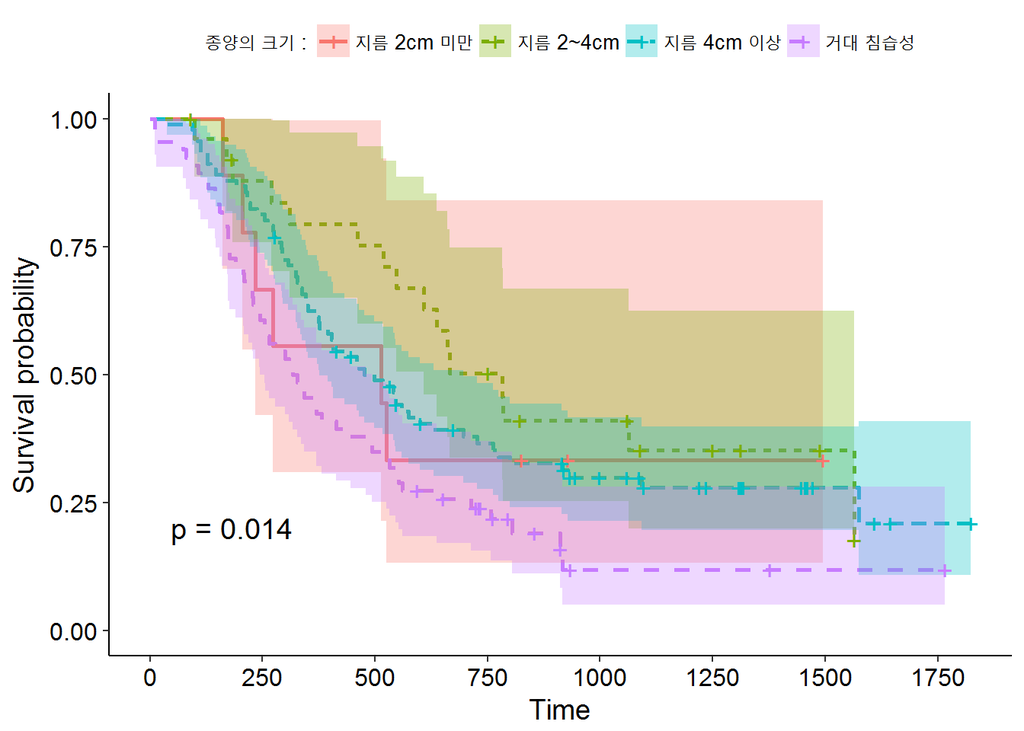

```r
KM_T_STAGE = survfit(Y ~ T_STAGE)
ggsurvplot(KM_T_STAGE, conf.int = T, break.time.by = 250, linetype = 'strata', legend.title = '종양의 크기 :', legend.labs = c('지름 2cm 미만', '지름 2~4cm', '지름 4cm 이상', '거대 침습성'), pval=T)
```

```r
survdiff(Y ~ T_STAGE)
```

```
## Call:
## survdiff(formula = Y ~ T_STAGE)
##
##            N Observed Expected (O-E)^2/E (O-E)^2/V
## T_STAGE=1  9        6     6.45     0.032    0.0337
## T_STAGE=2 26       16    23.78     2.546    3.1047
## T_STAGE=3 91       63    70.95     0.891    1.8346
## T_STAGE=4 66       54    37.81     6.927    9.6623
##
##  Chisq= 10.6  on 3 degrees of freedom, p= 0.0143
```

- p-value는 유의하나 종양의 크기에 따라 그룹별 신뢰구간을 포함한 Kaplan Meier Curve의 차이가 크게 존재하지 않는 것처럼 보인다.
- 종양의 지름 크기가 2cm 미만인 경우 데이터가 부족하여 위와같이 신뢰구간의 폭이 매우 넓은 형태로 나타났다.
- 어느 한 범주라도 데이터가 매우 부족하면 p-value에 큰 영향을 주어 결과 해석이 달라질 수 있다.
- `T_STAGE` 범주의 의미와 순서를 고려하여 거대 침습성 종양이 없으면 1, 있으면 2로 재구성하여 Kaplan Meier Curve를 다시 그린 결과는 다음과 같다.

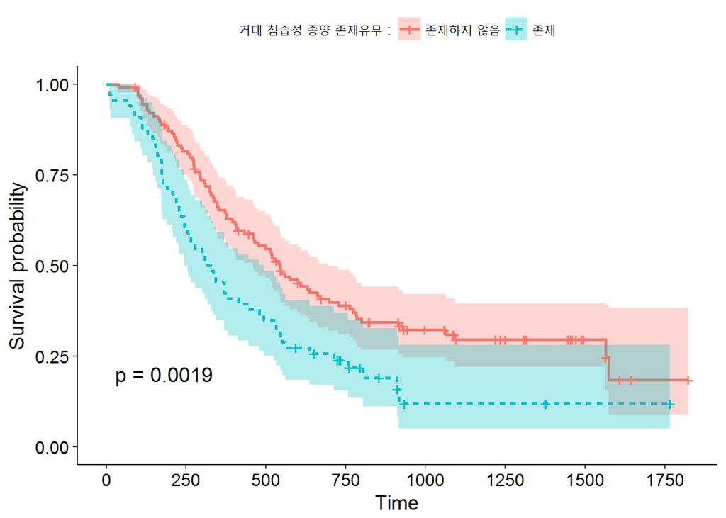

```r
T_STAGE[T_STAGE <= 3] <- 1
T_STAGE[T_STAGE == 4] <- 2

KM_T_STAGE = survfit(Y ~ T_STAGE)
ggsurvplot(KM_T_STAGE, conf.int = T, break.time.by = 250, linetype = 'strata', legend.title = '거대 침습성 종양 존재유무 :', legend.labs = c('존재하지 않음', '존재'), pval=T)
```

```r
survdiff(Y ~ T_STAGE)
```

```
## Call:
## survdiff(formula = Y ~ T_STAGE)
##
##             N Observed Expected (O-E)^2/E (O-E)^2/V
## T_STAGE=1 126       85    101.2      2.59      9.66
## T_STAGE=2  66       54     37.8      6.93      9.66
##
##  Chisq= 9.7  on 1 degrees of freedom, p= 0.00188
```

#### `N_STAGE(암세포의 전이 정도)`

- `N_STAGE`의 Kaplan Meier Curve

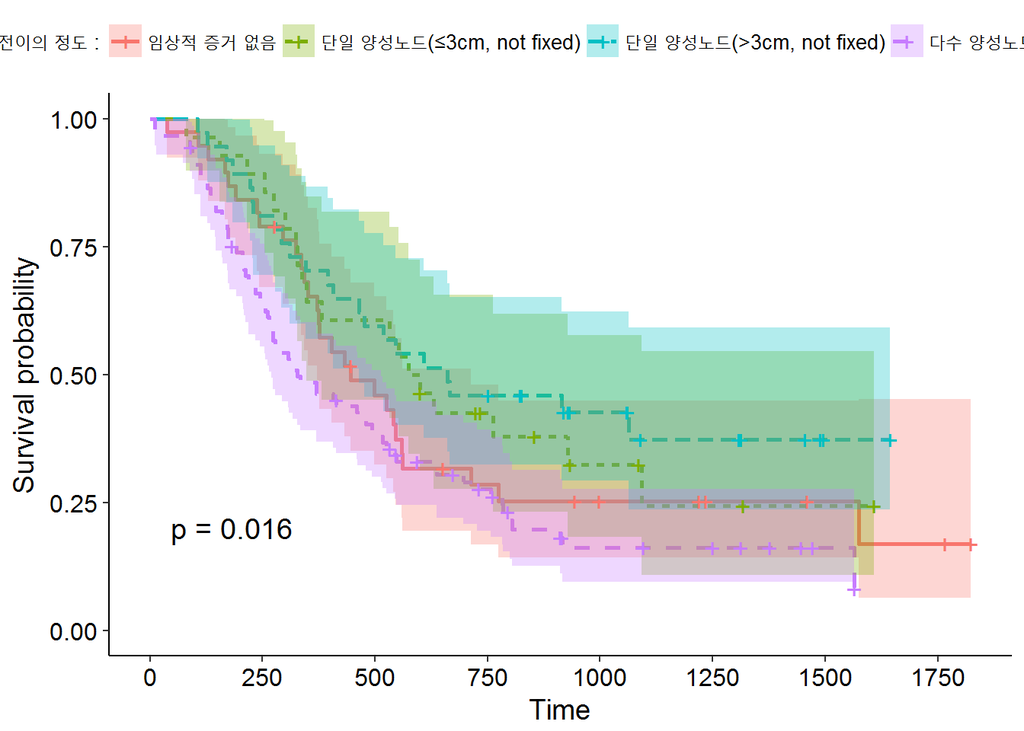

```r
KM_N_stage <- survfit(Y~N_STAGE)
ggsurvplot(KM_N_stage, conf.int = T, break.time.by = 250, linetype = 'strata', legend.title = '전이의 정도 :', legend.labs = c('임상적 증거 없음', '단일 양성노드(≤3cm, not fixed)', '단일 양성노드(>3cm, not fixed)', '다수 양성노드 또는 fixed'), pval=T)
```

```r
survdiff(Y ~ N_STAGE)
```

```
## Call:
## survdiff(formula = Y ~ N_STAGE)
##
##            N Observed Expected (O-E)^2/E (O-E)^2/V
## N_STAGE=0 38       28     28.7    0.0159    0.0203
## N_STAGE=1 28       19     24.0    1.0423    1.2636
## N_STAGE=2 37       22     33.2    3.7892    5.0280
## N_STAGE=3 89       70     53.1    5.3756    8.8162
##
##  Chisq= 10.4  on 3 degrees of freedom, p= 0.0158
```

- 위 `T_STAGE`의 결과와 유사하게 p-value는 유의하나 암세포의 전이 정도에 따라 그룹별 신뢰구간을 포함한 Kaplan Meier Curve의 차이가 크게 존재하지 않는 것처럼 보인다.
- 그룹간 차이를 보다 더 명확히 하기 위해 `N_STAGE` 범주의 의미와 순서를 고려하여 다수 또는 고정된 양성노드가 없으면 1, 있으면 2로 재구성하였다.

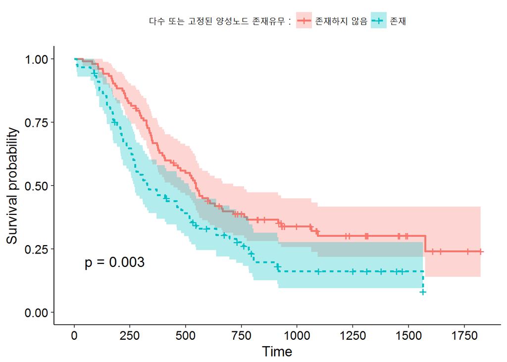

```r
N_STAGE[N_STAGE <= 2] <- 1
N_STAGE[N_STAGE == 3] <- 2
KM_N_stage <- survfit(Y~N_STAGE)
ggsurvplot(KM_N_stage, conf.int = T, break.time.by = 250, linetype = 'strata', legend.title = '다수 또는 고정된 양성노드 존재유무 :', legend.labs = c('존재하지 않음', '존재'), pval=T)
```

```r
survdiff(Y ~ N_STAGE)
```

```
## Call:
## survdiff(formula = Y ~ N_STAGE)
##
##             N Observed Expected (O-E)^2/E (O-E)^2/V
## N_STAGE=1 103       69     85.9      3.32      8.82
## N_STAGE=2  89       70     53.1      5.38      8.82
##
##  Chisq= 8.8  on 1 degrees of freedom, p= 0.00299
```

## 5. Select Variable

- COX Model을 적용하기 전 `TIME(생존시간)` 에 많은 영향을 주는 변수를 선정한다.
- 이때, **Stepwise** 방법을 이용하는데 이 중 `CASE`, `ENTRY_DT`, `STATUS`는 설명변수로 의미가 없으므로 제외한다.

```r
ph <- coxph(Y ~ factor(INST) + factor(SEX) + factor(TX) + factor(GRADE) + AGE + factor(COND) + factor(SITE) + factor(T_STAGE) + factor(N_STAGE))
stepAIC(ph, direction = "both")
```

```
## Start:  AIC=1266.32
## Y ~ factor(INST) + factor(SEX) + factor(TX) + factor(GRADE) +
##     AGE + factor(COND) + factor(SITE) + factor(T_STAGE) + factor(N_STAGE)
##
##                   Df    AIC
## - factor(INST)     5 1260.8
## - factor(SITE)     2 1263.1
## - AGE              1 1264.3
## - factor(TX)       1 1264.5
## <none>               1266.3
## - factor(GRADE)    1 1266.7
## - factor(SEX)      1 1266.9
## - factor(N_STAGE)  1 1267.5
## - factor(T_STAGE)  1 1267.6
## - factor(COND)     1 1293.8
##
## Step:  AIC=1260.81
## Y ~ factor(SEX) + factor(TX) + factor(GRADE) + AGE + factor(COND) +
##     factor(SITE) + factor(T_STAGE) + factor(N_STAGE)
##
##                   Df    AIC
## - factor(SITE)     2 1258.0
## - AGE              1 1258.9
## - factor(TX)       1 1259.1
## <none>               1260.8
## - factor(GRADE)    1 1261.0
## - factor(SEX)      1 1261.2
## - factor(N_STAGE)  1 1262.4
## - factor(T_STAGE)  1 1263.4
## + factor(INST)     5 1266.3
## - factor(COND)     1 1286.6
##
## Step:  AIC=1257.97
## Y ~ factor(SEX) + factor(TX) + factor(GRADE) + AGE + factor(COND) +
##     factor(T_STAGE) + factor(N_STAGE)
##
##                   Df    AIC
## - AGE              1 1256.0
## - factor(TX)       1 1256.5
## <none>               1258.0
```

[output cut: 24 more lines]

```
## Step:  AIC=1254.55
## Y ~ factor(SEX) + factor(GRADE) + factor(COND) + factor(T_STAGE) +
##     factor(N_STAGE)
##
##                   Df    AIC
## <none>               1254.5
## - factor(SEX)      1 1254.8
## - factor(GRADE)    1 1255.4
## - factor(N_STAGE)  1 1255.5
## + factor(TX)       1 1256.0
## + AGE              1 1256.5
## + factor(SITE)     2 1257.2
## - factor(T_STAGE)  1 1257.8
## + factor(INST)     5 1259.5
## - factor(COND)     1 1280.4
```

```
## Call:
## coxph(formula = Y ~ factor(SEX) + factor(GRADE) + factor(COND) +
##     factor(T_STAGE) + factor(N_STAGE))
##
##                    coef exp(coef) se(coef)     z       p
## factor(SEX)2     -0.309     0.734    0.211 -1.46   0.143
## factor(GRADE)2   -0.415     0.660    0.254 -1.63   0.103
## factor(COND)2     1.105     3.019    0.197  5.60 2.2e-08
## factor(T_STAGE)2  0.416     1.516    0.179  2.32   0.020
## factor(N_STAGE)2  0.313     1.367    0.182  1.72   0.085
##
## Likelihood ratio test=48.3  on 5 df, p=3.05e-09
## n= 192, number of events= 139
```

- AIC가 최소일 때의 Model을 최종적인 모형으로 출력함.
- 선택된 설명변수는 다음과 같다.
  - `SEX`, `GRADE`, `COND`, `T_STAGE`, `N_STAGE`
  - 여기서, `SEX`는 Kaplan Meier Curve를 그려보았을 때 큰 차이가 없으므로 제외한다.

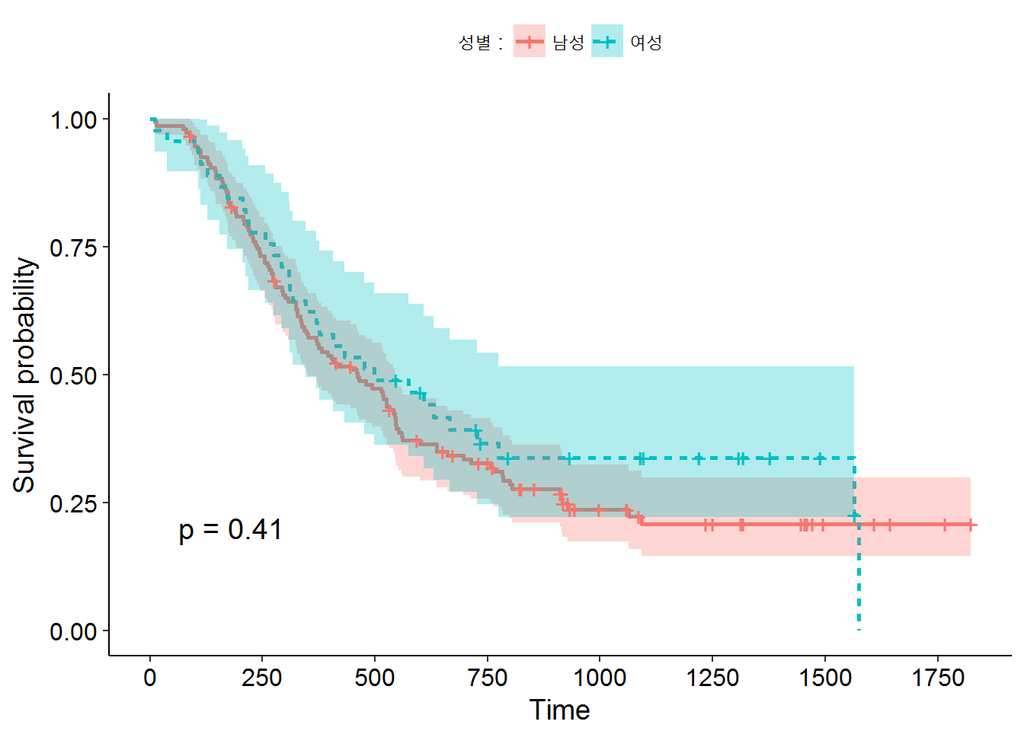

```r
KM_SEX <- survfit(Y~SEX)
ggsurvplot(KM_SEX, conf.int = T, break.time.by = 250, linetype = 'strata', legend.title = '성별 :', legend.labs = c('남성', '여성'), pval=T)
```

```r
survdiff(Y ~ SEX)
```

```
## Call:
## survdiff(formula = Y ~ SEX)
##
##         N Observed Expected (O-E)^2/E (O-E)^2/V
## SEX=1 147      108    103.8     0.174     0.688
## SEX=2  45       31     35.2     0.511     0.688
##
##  Chisq= 0.7  on 1 degrees of freedom, p= 0.407
```

- 즉, 최종적인 변수는 다음과 같다.
  - `GRADE`, `COND`, `T_STAGE`, `N_STAGE`

## 6. COX Model

- 선택된 설명변수로 COX Model을 생성하고, COX PH Assumption을 만족하는지 검정한다.

```r
ph <- coxph(Y ~  factor(GRADE) + factor(COND) + factor(T_STAGE) + factor(N_STAGE))
summary(ph)
```

```
## Call:
## coxph(formula = Y ~ factor(GRADE) + factor(COND) + factor(T_STAGE) +
##     factor(N_STAGE))
##
##   n= 192, number of events= 139
##
##                     coef exp(coef) se(coef)      z Pr(>|z|)
## factor(GRADE)2   -0.4639    0.6288   0.2515 -1.844   0.0651 .
## factor(COND)2     1.0343    2.8132   0.1909  5.419 5.99e-08 ***
## factor(T_STAGE)2  0.4096    1.5062   0.1794  2.283   0.0224 *
## factor(N_STAGE)2  0.3384    1.4027   0.1804  1.876   0.0606 .
## ---
## Signif. codes:  0 '***' 0.001 '**' 0.01 '*' 0.05 '.' 0.1 ' ' 1
##
##                  exp(coef) exp(-coef) lower .95 upper .95
## factor(GRADE)2      0.6288     1.5903    0.3841     1.029
## factor(COND)2       2.8132     0.3555    1.9352     4.090
## factor(T_STAGE)2    1.5062     0.6639    1.0597     2.141
## factor(N_STAGE)2    1.4027     0.7129    0.9850     1.998
##
## Concordance= 0.693  (se = 0.026 )
## Rsquare= 0.213   (max possible= 0.999 )
## Likelihood ratio test= 46.07  on 4 df,   p=2.378e-09
## Wald test            = 51.02  on 4 df,   p=2.211e-10
## Score (logrank) test = 55.71  on 4 df,   p=2.311e-11
```

```r
cox.zph(ph,transform=rank)
```

```
##                      rho  chisq       p
## factor(GRADE)2   -0.1132  1.775 0.18281
## factor(COND)2    -0.2546  8.716 0.00315
## factor(T_STAGE)2 -0.1255  2.207 0.13734
## factor(N_STAGE)2 -0.0491  0.358 0.54971
## GLOBAL                NA 14.759 0.00523
```

- 그 결과 위의 Model은 COX PH Assumption을 만족하지 않는다.
- 그 원인을 살펴보았을 때 다른 설명변수는 PH Assumption을 만족하지만 `COND` 설명변수가 PH Assumption을 만족하지 않기 때문이다.
- 따라서, `COND`는 층화변수로 설정하고 Cox Model을 적용한다.

```r
model1 <- coxph(Y ~ factor(GRADE) + strata(factor(COND)) + factor(T_STAGE) + factor(N_STAGE))
cox.zph(model1,transform=rank)
```

```
##                     rho chisq     p
## factor(GRADE)2   -0.106 1.571 0.210
## factor(T_STAGE)2 -0.103 1.518 0.218
## factor(N_STAGE)2 -0.034 0.168 0.682
## GLOBAL               NA 3.499 0.321
```

```r
summary(model1)
```

```
## Call:
## coxph(formula = Y ~ factor(GRADE) + strata(factor(COND)) + factor(T_STAGE) +
##     factor(N_STAGE))
##
##   n= 192, number of events= 139
##
##                     coef exp(coef) se(coef)      z Pr(>|z|)
## factor(GRADE)2   -0.4162    0.6595   0.2520 -1.652   0.0985 .
## factor(T_STAGE)2  0.4621    1.5873   0.1818  2.542   0.0110 *
## factor(N_STAGE)2  0.3986    1.4897   0.1804  2.209   0.0272 *
## ---
## Signif. codes:  0 '***' 0.001 '**' 0.01 '*' 0.05 '.' 0.1 ' ' 1
##
##                  exp(coef) exp(-coef) lower .95 upper .95
## factor(GRADE)2      0.6595     1.5162    0.4025     1.081
## factor(T_STAGE)2    1.5873     0.6300    1.1116     2.267
## factor(N_STAGE)2    1.4897     0.6713    1.0460     2.122
##
## Concordance= 0.624  (se = 0.033 )
## Rsquare= 0.085   (max possible= 0.997 )
## Likelihood ratio test= 16.98  on 3 df,   p=0.0007133
## Wald test            = 17.22  on 3 df,   p=0.0006364
## Score (logrank) test = 17.62  on 3 df,   p=0.0005265
```

- 그 결과 PH Assumption을 만족하는 것을 확인할 수 있다.
- 또한 Cox Model의 Summary를 살펴보면 다음과 같다.
- 악성종양과 숙주세포가 서로 유사하면(`GRADE`=1), 유사하지 않을 때보다 hazard가 exp(0.4162), 약 1.52배이다.
- 거대 침습성 종양이 존재하면(`T_STAGE`=2), 존재하지 않을 때보다 hazard가 exp(0.4621), 약 1.59배이다.
- 다수 또는 고정된 양성노드가 존재하면(`N_STAGE`=2), 존재하지 않을 때보다 hazard가 exp(0.3986), 약 1.49배이다.
- 환자의 건강상태(`COND`)는 층화하였기 때문에 특정그룹에 대한 hazard를 표현하기 어렵다. 따라서 다른 설명변수들의 조건이 동일할 때 건강상태에 따른 차이를 아래의 plot으로 알아보았다.
- 설명변수 조건 설정 : 악성종양이 숙주세포와 유사하고, 거대 침윤성 종양 및 2개 이상의 양성노드를 가진 환자의 경우 다음과 같은 패턴을 확인할 수 있다.

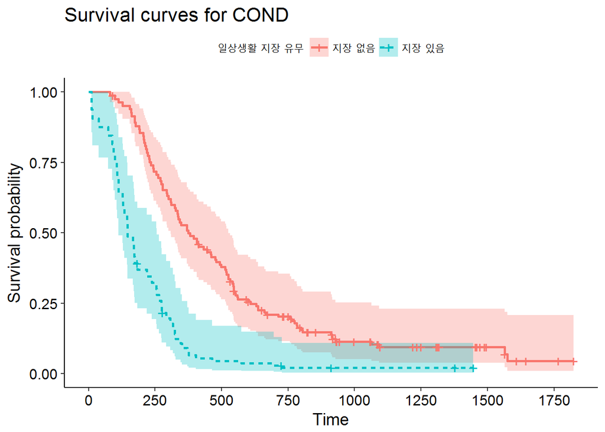

```r
pattern1 <- data.frame(GRADE = factor(1), T_STAGE = factor(2), N_STAGE = factor(2))
ggsurvplot(survfit(model1, newdata=pattern1), conf.int = T, break.time.by = 250, linetype = 'strata', legend.title = '일상생활 지장 유무', legend.labs = c('지장 없음', '지장 있음'), main='Survival curves for COND')
```

- 설명변수의 조건을 동일하게 설정한 상태에서 `COND`를 층화하였을 때, 전시점에서 일상생활에 지장이 없는 그룹의 생존확률이 지장있는 그룹보다 항상 높다는 것을 확인할 수 있다.

## 7. AFT Model

### The Assumption of Distribution

- AFT Model을 적용하기 전 분포를 가정한다.
  - 분포는 weibull, exponential, lognormal, loglogistic 적용
  - AIC가 최소인 분포를 선정
  - AIC = -2*Loglikihood + 2(q + 2 + k) 이용
  - q : 공변량 수
  - k : 0(exponential), 1(weibull, loglogistic, lognormal), 2(gamma)

```r
# exponential
AFT_model_exponential <- survreg(Y ~ factor(INST) + factor(SEX) + factor(TX) + factor(GRADE) + AGE + factor(COND) + factor(SITE) + factor(T_STAGE) + factor(N_STAGE), dist = "exponential")

# weibull
AFT_model_weibull <- survreg(Y ~ factor(INST) + factor(SEX) + factor(TX) + factor(GRADE) + AGE + factor(COND) + factor(SITE) + factor(T_STAGE) + factor(N_STAGE), dist = "weibull")

# lognormal
AFT_model_lognormal <- survreg(Y ~ factor(INST) + factor(SEX) + factor(TX) + factor(GRADE) + AGE + factor(COND) + factor(SITE) + factor(T_STAGE) + factor(N_STAGE), dist = "lognormal")

# loglogistic
AFT_model_loglogistic <- survreg(Y ~ factor(INST) + factor(SEX) + factor(TX) + factor(GRADE) + AGE + factor(COND) + factor(SITE) + factor(T_STAGE) + factor(N_STAGE), dist = "loglogistic")

# AIC
AIC_weibull <- -2*AFT_model_weibull$loglik[2] + 2*(9 + 2 + 1)
AIC_exponential <- -2*AFT_model_exponential$loglik[2] + 2*(9 + 2 + 0)
AIC_lognormal <- -2*AFT_model_lognormal$loglik[2] + 2*(9 + 2 + 1)
AIC_loglogistic <- -2*AFT_model_loglogistic$loglik[2] + 2*(9 + 2 + 1)
data.frame(AIC_weibull=AIC_weibull, AIC_exponential=AIC_exponential, AIC_lognormal=AIC_lognormal, AIC_loglogistic=AIC_loglogistic)
```

```
##   AIC_weibull AIC_exponential AIC_lognormal AIC_loglogistic
## 1    2090.651        2098.665      2065.614        2064.996
```

- AIC가 최소인 분포로 log-logistic 이 2064.996으로 가장 작았으므로 AFT 모형 적용 시 log-logistic 분포를 선정한다.

### Select Variable

- AFT 모형구축 과정에 관한 방법은 아래의 그림과 같다.

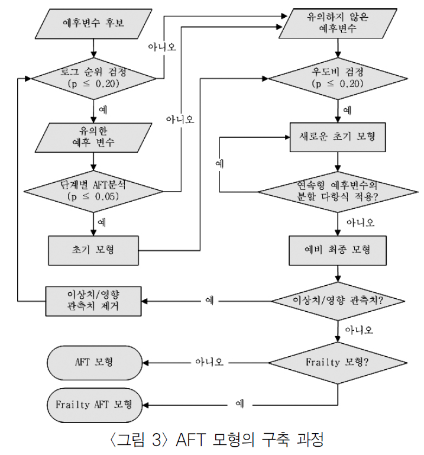

```r
## Full Model
full_AFT_model <- survreg(Y ~ factor(SEX) + factor(TX) + factor(SITE) + AGE + factor(COND) + factor(T_STAGE) + factor(N_STAGE), dist = "loglogistic")

## Reduced Model
reduced_AFT_model <- survreg(Y ~ factor(GRADE) + factor(COND) + factor(T_STAGE) + factor(N_STAGE), dist = "loglogistic")

lrtest(full_AFT_model, reduced_AFT_model)
```

```
## Likelihood ratio test
##
## Model 1: Y ~ factor(SEX) + factor(TX) + factor(SITE) + AGE + factor(COND) +
##     factor(T_STAGE) + factor(N_STAGE)
## Model 2: Y ~ factor(GRADE) + factor(COND) + factor(T_STAGE) + factor(N_STAGE)
##   #Df  LogLik Df  Chisq Pr(>Chisq)
## 1  10 -1022.7
## 2   6 -1023.4 -4 1.2766     0.8653
```

### proportional odds assumption

- 위에서 구성한 AFT model에서 각 공변량에 대해 비례 odds 가정을 만족하는지 확인하면 다음과 같다.

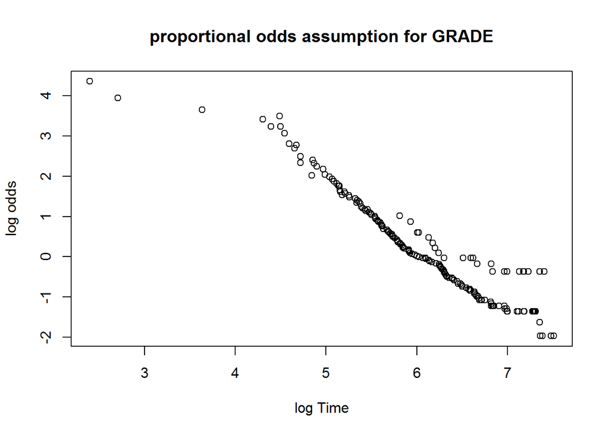

```r
plot(log(KM_GRADE$time), log(KM_GRADE$surv/(1-KM_GRADE$surv)), xlab='log Time', ylab='log odds', main='proportional odds assumption for GRADE')
```

- `GRADE(악성종양과 숙주세포와의 유사도)`에서는 GRADE=1에 대한 plot은 직선 형태를 보이지만, GRADE=2에 대해서는 데이터가 다소 부족하여 plot 형태를 판단하기 어렵다. 따라서, 데이터가 더 많이 충족될 때 비례 odds 가정을 만족하는지 보다 더 정확하게 확인할 수 있을 것이다.

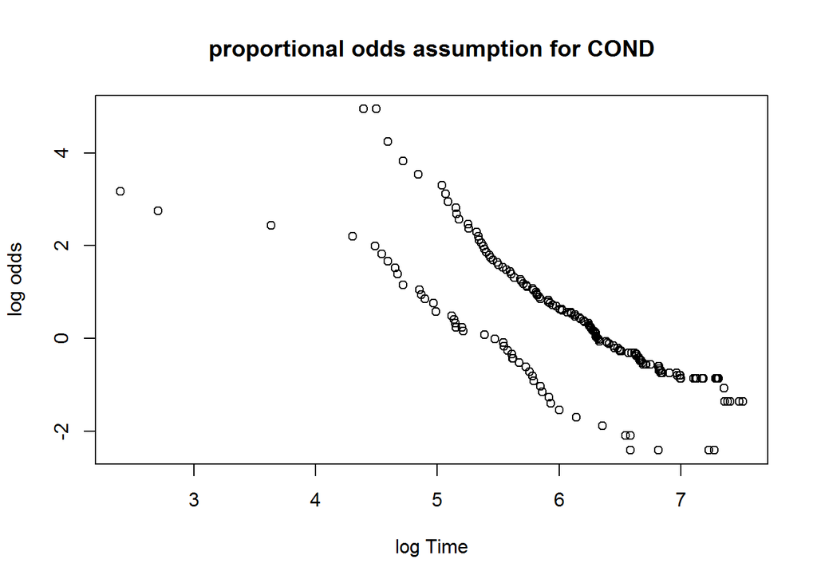

```r
plot(log(KM_COND$time), log(KM_COND$surv/(1-KM_COND$surv)), xlab='log Time', ylab='log odds', main='proportional odds assumption for COND')
```

- `COND(환자의 건강상태)`에서는 두 그룹의 plot이 비교적 직선 형태를 띄고, 서로 평행한 것을 보아 비례 odds 가정을 만족한다고 볼 수 있다.

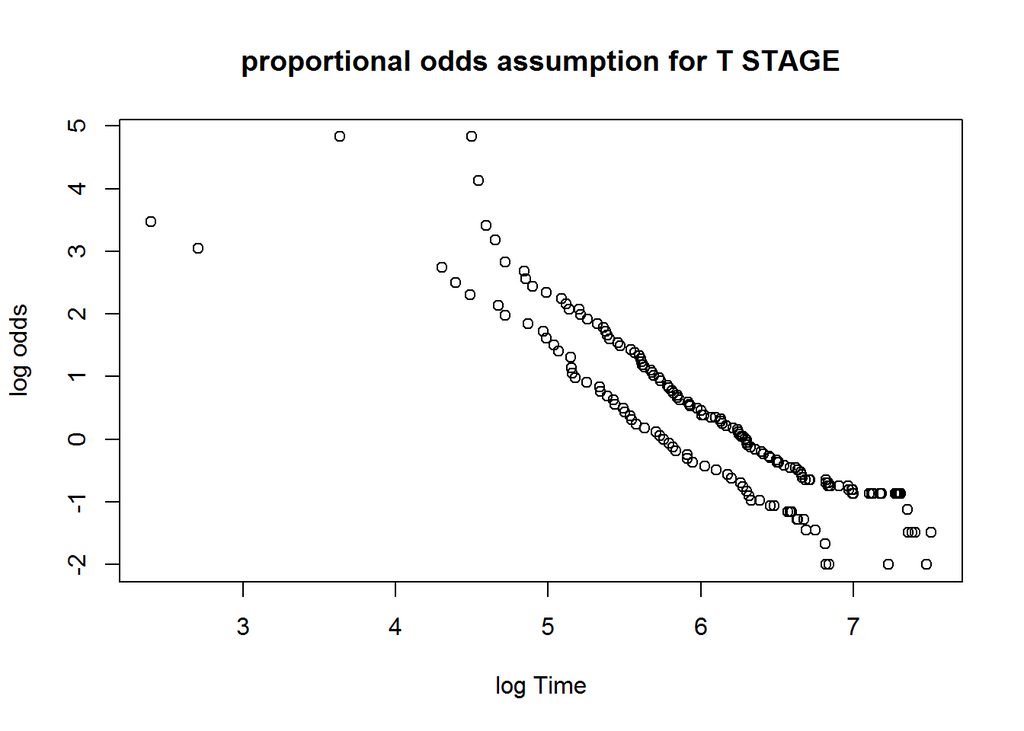

```r
plot(log(KM_T_STAGE$time), log(KM_T_STAGE$surv/(1-KM_T_STAGE$surv)), xlab='log Time', ylab='log odds', main='proportional odds assumption for T STAGE')
```

- `T_STAGE(종양의 크기)`에서 또한 두 그룹의 plot이 비교적 직선 형태를 띄고, 서로 평행한 것을 보아 비례 odds 가정을 만족한다고 볼 수 있다.

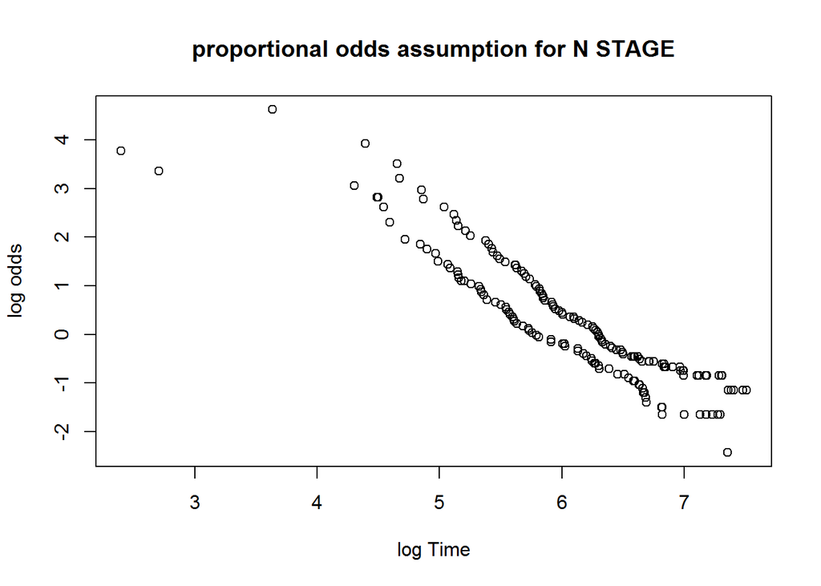

```r
plot(log(KM_N_stage$time), log(KM_N_stage$surv/(1-KM_N_stage$surv)), xlab='log Time', ylab='log odds', main='proportional odds assumption for N STAGE')
```

- `N_STAGE(암세포의 전이 정도)` 역시 두 그룹의 plot이 비교적 직선 형태를 띄고, 서로 평행한 것을 보아 비례 odds 가정을 만족한다고 볼 수 있다.

### AFT Model

```r
(reduced_AFT_model <- survreg(Y ~ factor(GRADE) + factor(COND) + factor(T_STAGE) + factor(N_STAGE), dist = "loglogistic"))
```

```
## Call:
## survreg(formula = Y ~ factor(GRADE) + factor(COND) + factor(T_STAGE) +
##     factor(N_STAGE), dist = "loglogistic")
##
## Coefficients:
##      (Intercept)   factor(GRADE)2    factor(COND)2 factor(T_STAGE)2
##        6.7166885        0.2709129       -1.0186259       -0.4899237
## factor(N_STAGE)2
##       -0.3689889
##
## Scale= 0.5319837
##
## Loglik(model)= -1023.4   Loglik(intercept only)= -1053.6
##  Chisq= 60.5 on 4 degrees of freedom, p= 2.3e-12
## n= 192
```

## 8. 결론

- Cox PH 및 AFT 모형을 이용할 때, 큰 맥락으로 판단할 경우 서로 다른 그룹에 대한 비교, 해석시 비슷한 결과가 도출된다는 것을 알 수 있다.
- 그러나 세부적으로 판단할 경우 hazard 개념을 이용한 Cox PH 모형보다는 **생존시간을 이용한 AFT 모형이 해석에 있어서 더 직관적이고 이해하기 쉽다.**

## Appendix

#### `INST(연구기관)의 Kaplan Meier Curve`

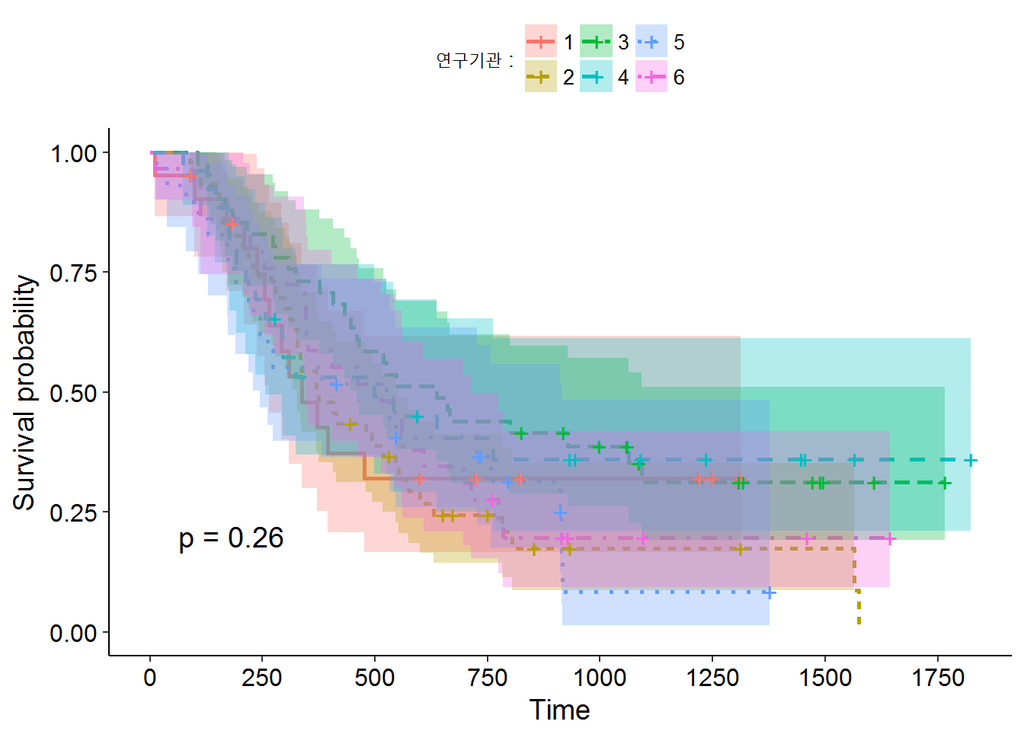

```r
KM_INST = survfit(Y ~ INST)
ggsurvplot(KM_INST, conf.int = T, break.time.by = 250, linetype = 'strata', legend.title = '연구기관 :', legend.labs = c(1:6), pval = T)
```

```r
survdiff(Y ~ INST)
```

```
## Call:
## survdiff(formula = Y ~ INST)
##
##         N Observed Expected (O-E)^2/E (O-E)^2/V
## INST=1 21       13     12.2    0.0504    0.0555
## INST=2 46       38     29.7    2.3009    2.9612
## INST=3 41       27     37.1    2.7578    3.8145
## INST=4 26       16     19.4    0.5955    0.6966
## INST=5 29       22     18.8    0.5489    0.6394
## INST=6 29       23     21.8    0.0718    0.0853
##
##  Chisq= 6.5  on 5 degrees of freedom, p= 0.263
```

#### `TX(치료요법)의 Kaplan Meier Curve`

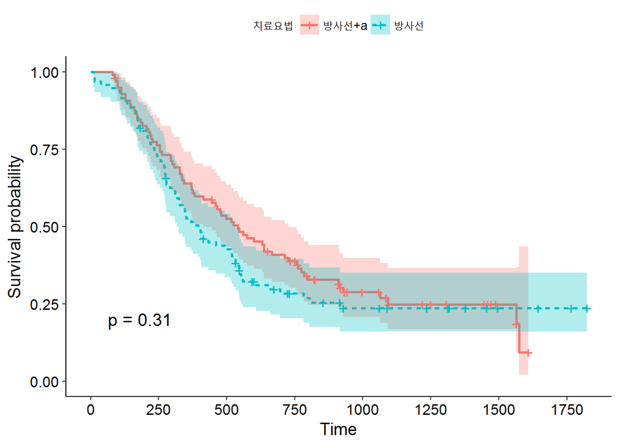

```r
KM_TX = survfit(Y ~ TX)
ggsurvplot(KM_TX, conf.int = T, break.time.by = 250, linetype = 'strata', legend.title = '치료요법', legend.lab = c('방사선+a', '방사선'), pval = T)
```

```r
survdiff(Y ~ TX)
```

```
## Call:
## survdiff(formula = Y ~ TX)
##
##       N Observed Expected (O-E)^2/E (O-E)^2/V
## TX=1 98       71       77     0.461      1.04
## TX=2 94       68       62     0.571      1.04
##
##  Chisq= 1  on 1 degrees of freedom, p= 0.308
```

#### `SITE(종양의 부위)의 Kaplan Meier Curve`

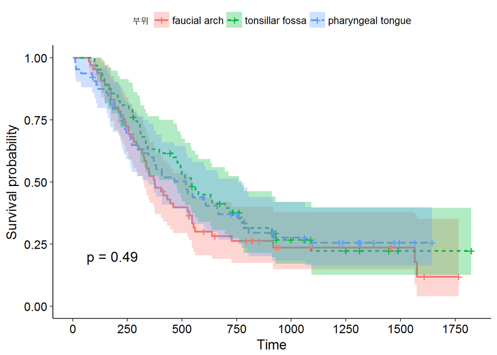

```r
KM_SITE = survfit(Y ~ SITE)
ggsurvplot(KM_SITE, conf.int = T, break.time.by = 250, linetype = 'strata', legend.title = '부위', legend.lab = c('faucial arch', 'tonsillar fossa', 'pharyngeal tongue'), pval = T)
```

```r
survdiff(Y ~ SITE)
```

```
## Call:
## survdiff(formula = Y ~ SITE)
##
##         N Observed Expected (O-E)^2/E (O-E)^2/V
## SITE=1 65       50     43.7    0.9031    1.3327
## SITE=2 63       44     48.8    0.4788    0.7421
## SITE=4 64       45     46.4    0.0451    0.0682
##
##  Chisq= 1.4  on 2 degrees of freedom, p= 0.486
```

- 한국외대 통계학과
- 김종영, 김선화, 김준영